# Practical Machine Learning - Human Activity Recognition Project

Antonio Rueda

February 14th, 2016

## Intro and goal

The goal of your project is to predict the manner in which they did the exercise. This is the **classe** variable in the training set. You may use any of the other variables to predict with.

You should create a report describing how you built your model, how you used cross validation, what you think the expected out of sample error is, and why you made the choices you did. You will also use your prediction model to predict 20 different test cases.

## Data download

Remember to set working directory as this Rmd file’s location.

## Setting up testing and training data frames

```r
trainingDataRaw <- read.csv("./data/pml-training.csv")
testingDataRaw <- read.csv("./data/pml-testing.csv")
dim(trainingDataRaw)
```

```
## [1] 19622   160
```

```r
dim(testingDataRaw)
```

```
## [1]  20 160
```

## Data cleaning

```r
sum(complete.cases(trainingDataRaw))
```

```
## [1] 406
```

Remove colums with missing values.

```r
trainingDataRaw <- trainingDataRaw[, colSums(is.na(trainingDataRaw)) == 0]
testingDataRaw <- testingDataRaw[, colSums(is.na(testingDataRaw)) == 0]
```

Remove columns with low contribution to the accelerometer measurements.

```r
classe <- trainingDataRaw$classe
trainRemove <- grepl("X|timestamp|window", names(trainingDataRaw))
trainingDataRaw <- trainingDataRaw[, !trainRemove]
trainCleaned <- trainingDataRaw[, sapply(trainingDataRaw, is.numeric)]
trainCleaned$classe <- classe
testRemove <- grepl("^X|timestamp|window", names(testingDataRaw))
testingDataRaw <- testingDataRaw[, !testRemove]
cleanedTestData <- testingDataRaw[, sapply(testingDataRaw, is.numeric)]

dim(cleanedTestData)
```

```
## [1] 20 53
```

```r
dim(trainCleaned)
```

```
## [1] 19622    53
```

```r
set.seed(11)
inTrain <- createDataPartition(trainCleaned$classe, p=0.80, list = F)
trainData <- trainCleaned[inTrain, ]
testData <- trainCleaned[-inTrain, ]
```

## Predictive Model

We’ll use an ensemble of decision trees, a “random forest”, as predictive model. Decision trees are invariant under scaling and various other transformations of feature values, are robust to the inclusion of irrelevant features, and produces inspectable models. We ch to use an ensemble of decision trees to increase predictive accuracy. This ensemble provides attractive tradeoff between computational cost and predictive power. A random forest is also typically robust to outliers and automatically ranks features according to importance.

```r
controlRandomForest <- trainControl(method="cv", 5) #5-fold cross validation
randomForestModel <- train(classe ~ ., data=trainData, method = "rf",trControl=controlRandomForest, ntree=200)
randomForestModel
```

```
## Random Forest
##
## 15699 samples
##    52 predictor
##     5 classes: 'A', 'B', 'C', 'D', 'E'
##
## No pre-processing
## Resampling: Cross-Validated (5 fold)
## Summary of sample sizes: 12560, 12559, 12559, 12558, 12560
## Resampling results across tuning parameters:
##
##   mtry  Accuracy   Kappa      Accuracy SD  Kappa SD
##    2    0.9913373  0.9890415  0.001791627  0.002266791
##   27    0.9914010  0.9891225  0.001785194  0.002258831
##   52    0.9841396  0.9799351  0.003078944  0.003893976
##
## Accuracy was used to select the optimal model using  the largest value.
## The final value used for the model was mtry = 27.
```

## Visualizations

Correlation matrix in the training set

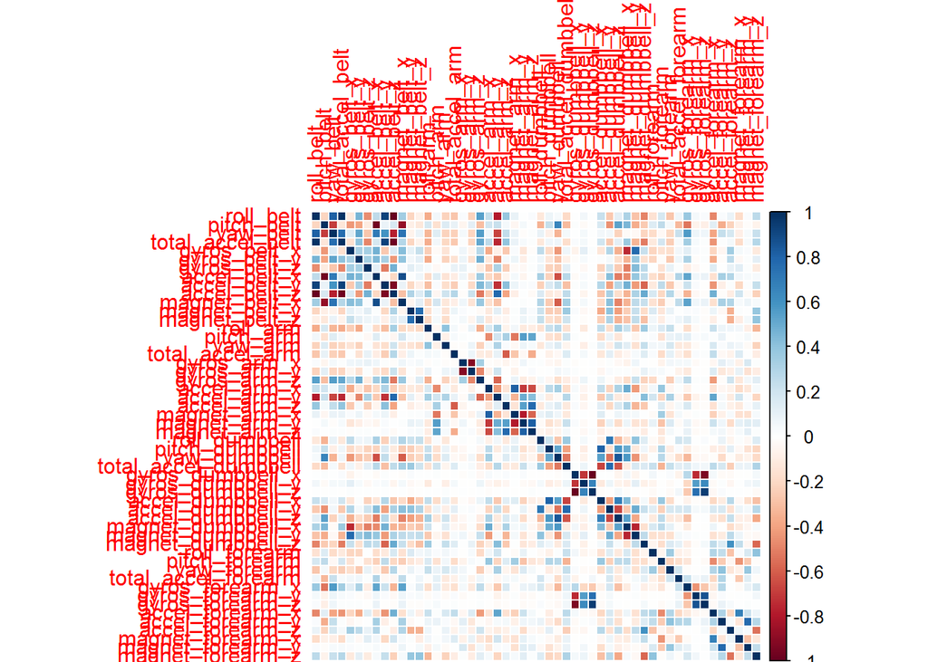

```r
corrPlot <- cor(trainData[, -length(names(trainData))])
corrplot(corrPlot, method="color")
```

Decision tree

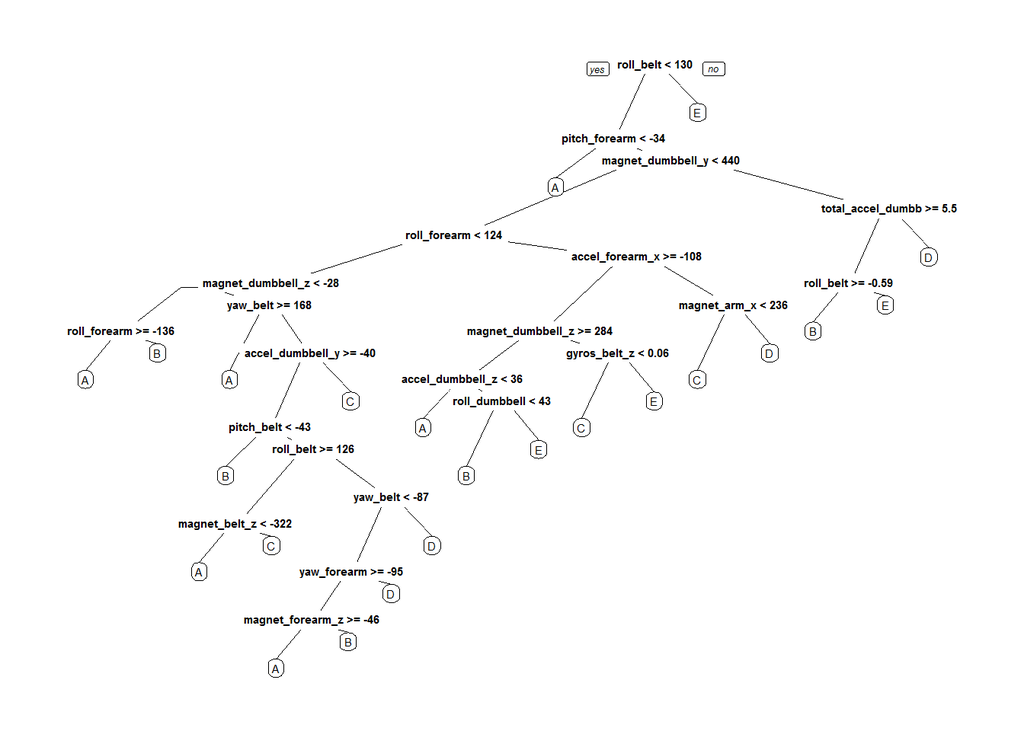

```r
treeModel <- rpart(classe ~ ., data=trainData, method="class")
prp(treeModel)
```

We validate the performance of the random forest model in the testing set.

```r
randomForestPrediction <- predict(randomForestModel, testData)
confusionMatrix(testData$classe, randomForestPrediction)
```

```
## Confusion Matrix and Statistics
##
##           Reference
## Prediction    A    B    C    D    E
##          A 1116    0    0    0    0
##          B    5  753    1    0    0
##          C    0    2  681    1    0
##          D    0    0    7  636    0
##          E    0    0    0    3  718
##
## Overall Statistics
##
##                Accuracy : 0.9952
##                  95% CI : (0.9924, 0.9971)
##     No Information Rate : 0.2858
##     P-Value [Acc > NIR] : < 2.2e-16
##
##                   Kappa : 0.9939
##  Mcnemar's Test P-Value : NA
##
## Statistics by Class:
##
##                      Class: A Class: B Class: C Class: D Class: E
## Sensitivity            0.9955   0.9974   0.9884   0.9938   1.0000
## Specificity            1.0000   0.9981   0.9991   0.9979   0.9991
## Pos Pred Value         1.0000   0.9921   0.9956   0.9891   0.9958
## Neg Pred Value         0.9982   0.9994   0.9975   0.9988   1.0000
## Prevalence             0.2858   0.1925   0.1756   0.1631   0.1830
## Detection Rate         0.2845   0.1919   0.1736   0.1621   0.1830
## Detection Prevalence   0.2845   0.1935   0.1744   0.1639   0.1838
## Balanced Accuracy      0.9978   0.9977   0.9937   0.9958   0.9995
```

```r
accuracy <- postResample(randomForestPrediction, testData$classe)
accuracy
```

```
##  Accuracy     Kappa
## 0.9951568 0.9938730
```

```r
outOfSampleError <- 1 - as.numeric(confusionMatrix(testData$classe, randomForestPrediction)$overall[1])
outOfSampleError
```

```
## [1] 0.004843232
```

The random forest model has an accuracy of 0.99 and an estimated out of sample error of 0.005.

## Predictions on the Testing Set

We apply the model to the downloaded testing set and report the results below.

```r
result <- predict(randomForestModel, cleanedTestData[, -length(names(cleanedTestData))])
result
```

```
##  [1] B A B A A E D B A A B C B A E E A B B B
## Levels: A B C D E
```